# GO Term Overlap Analysis

Ingo Müller

2025-12-16

# GO-term venn diagrams

Explore the overlap between different functional annotation methods

## Initial setup

Clear workspace and load the necessary packages.

```r
rm(list = ls())

# Load required packages
library(tidyverse)
library(ggVennDiagram)
library(grid)
library(gridExtra)

# Set working directory!
PATH <- "/home/ingomue/1.Work/1.Projects/2025_Aquarius/06.func_annot/"
setwd(PATH)
```

## Loading and preprocess data

Load each tsv and make lists of unique go terms and genes Also put each feature together with its associated GO-terms and genes to see how much those overlap diamond. By features, I refer to anything that was annotated by the structural annotation by `braker`, most commonly these will be transcripts and CDS (`eggnog` only annotates CDS), e.g. in the gff they will be labelled as `g23.t1` (gene 23, transcript 1).

Also an important note is that the `interpro+BLAST` annotation builds on top of the `interpro` annotation, so I expect significant overlap and no exclusive GO-terms/genes in the `interpro` annotation.

```r
# EggNOG with DIAMOND alignment
egg_diamond <- read.table(paste0(PATH, "01.input/eggnog_diamond.tsv"),
                          header = T,sep = "\t", quote = "")

# 1. All unique genes (excluding NA)
egg_dia_genes <- unique(egg_diamond$GENE[!is.na(egg_diamond$GENE)])

# 2. All unique GO terms (excluding NA)
egg_diamond_uniq <- egg_diamond %>%
  filter(!is.na(GO)) %>%
  separate_rows(GO, sep = ",") %>%
  mutate(GO = str_trim(GO)) %>%
  pull(GO) %>%
  unique()

# 3. Features + genes
egg_diamond_featgen <- egg_diamond %>%
  filter(!is.na(GENE)) %>%
  mutate(feat_gene = paste(seqid, GENE, sep = "_")) %>%
  pull(feat_gene)

# 4. Features + GO terms
egg_diamond_featGO <- egg_diamond %>%
  filter(!is.na(GO)) %>%
  separate_rows(GO, sep = ",") %>%
  mutate(GO = str_trim(GO),
         feat_GO = paste(seqid, GO, sep = "_")) %>%
  pull(feat_GO)

# EggNOG with mmseqs2 on default mode
egg_mm_def <- read.table(paste0(PATH, "01.input/eggnog_mm_def.tsv"),
                         header = T,sep = "\t", quote = "")

egg_mm_def_genes <- unique(egg_mm_def$GENE[!is.na(egg_mm_def$GENE)])

egg_mm_def_uniq <- egg_mm_def %>%
  filter(!is.na(GO)) %>%
  separate_rows(GO, sep = ",") %>%
  mutate(GO = str_trim(GO)) %>%
  pull(GO) %>%
  unique()

egg_mm_def_featgen <- egg_mm_def %>%
  filter(!is.na(GENE)) %>%
  mutate(feat_gene = paste(seqid, GENE, sep = "_")) %>%
  pull(feat_gene)

egg_mm_def_featGO <- egg_mm_def %>%
  filter(!is.na(GO)) %>%
  separate_rows(GO, sep = ",") %>%
  mutate(GO = str_trim(GO),
         feat_GO = paste(seqid, GO, sep = "_")) %>%
  pull(feat_GO)

# EggNOG with mmseqs2 on high-sensitivity mode
egg_mm_HC <- read.table(paste0(PATH, "01.input/eggnog_mm_HS.tsv"),
                         header = T,sep = "\t", quote = "")

egg_mm_HC_genes <- unique(egg_mm_HC$GENE[!is.na(egg_mm_HC$GENE)])

egg_mm_HC_uniq <- egg_mm_HC %>%
  filter(!is.na(GO)) %>%
  separate_rows(GO, sep = ",") %>%
  mutate(GO = str_trim(GO)) %>%
  pull(GO) %>%
  unique()

egg_mm_HC_featgen <- egg_mm_HC %>%
  filter(!is.na(GENE)) %>%
  mutate(feat_gene = paste(seqid, GENE, sep = "_")) %>%
  pull(feat_gene)

egg_mm_HC_featGO <- egg_mm_HC %>%
  filter(!is.na(GO)) %>%
  separate_rows(GO, sep = ",") %>%
  mutate(GO = str_trim(GO),
         feat_GO = paste(seqid, GO, sep = "_")) %>%
  pull(feat_GO)

# InterProScan
interpro <- read.table(paste0(PATH, "01.input/interpro.tsv"),
                  header = T, sep = "\t", quote = "")

interpro_genes <- unique(interpro$GENE[!is.na(interpro$GENE)])

interpro_uniq <- interpro %>%
  filter(!is.na(GO)) %>%
  separate_rows(GO, sep = ",") %>%
  mutate(GO = str_trim(GO)) %>%
  pull(GO) %>%
  unique()

interpro_featgen <- interpro %>%
  filter(!is.na(GENE)) %>%
  mutate(feat_gene = paste(seqid, GENE, sep = "_")) %>%
  pull(feat_gene)

interpro_featGO <- interpro %>%
  filter(!is.na(GO)) %>%
  separate_rows(GO, sep = ",") %>%
  mutate(GO = str_trim(GO),
         feat_GO = paste(seqid, GO, sep = "_")) %>%
  pull(feat_GO)

# InterProScan + BLAST
interpro_blast <- read.table(paste0(PATH, "01.input/interpro_blast.tsv"),
                       header = T, sep = "\t", quote = "")

interpro_blast_genes <- unique(interpro_blast$GENE[!is.na(interpro_blast$GENE)])

interpro_blast_uniq <- interpro_blast %>%
  filter(!is.na(GO)) %>%
  separate_rows(GO, sep = ",") %>%
  mutate(GO = str_trim(GO)) %>%
  pull(GO) %>%
  unique()

interpro_blast_featgen <- interpro_blast %>%
  filter(!is.na(GENE)) %>%
  mutate(feat_gene = paste(seqid, GENE, sep = "_")) %>%
  pull(feat_gene)

interpro_blast_featGO <- interpro_blast %>%
  filter(!is.na(GO)) %>%
  separate_rows(GO, sep = ",") %>%
  mutate(GO = str_trim(GO),
         feat_GO = paste(seqid, GO, sep = "_")) %>%
  pull(feat_GO)
```

## 1) EggNOG with mmseqs2 default vs high-sensitivity modes

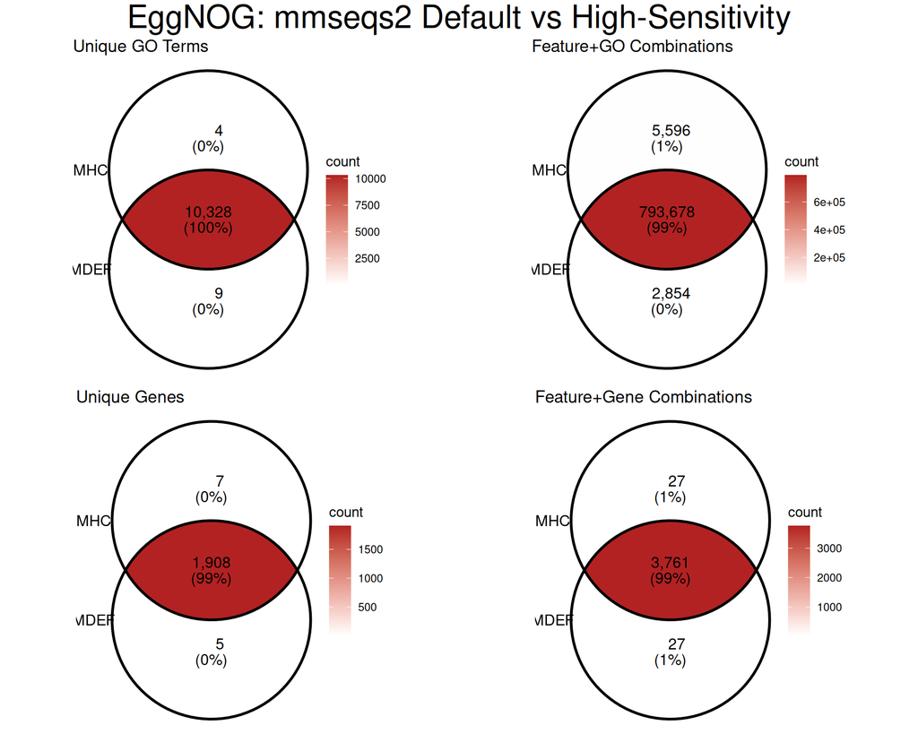

```r
# Create all 4 plots
p1 <- ggVennDiagram(list(MMDEF=egg_mm_def_uniq, MMHC=egg_mm_HC_uniq), label_alpha = 0) +
  scale_fill_gradient(low="white", high="firebrick") +
  ggtitle("Unique GO Terms")

p2 <- ggVennDiagram(list(MMDEF=egg_mm_def_featGO, MMHC=egg_mm_HC_featGO), label_alpha = 0) +
  scale_fill_gradient(low="white", high="firebrick") +
  ggtitle("Feature+GO Combinations")

p3 <- ggVennDiagram(list(MMDEF=egg_mm_def_genes, MMHC=egg_mm_HC_genes), label_alpha = 0) +
  scale_fill_gradient(low="white", high="firebrick") +
  ggtitle("Unique Genes")

p4 <- ggVennDiagram(list(MMDEF=egg_mm_def_featgen, MMHC=egg_mm_HC_featgen), label_alpha = 0) +
  scale_fill_gradient(low="white", high="firebrick") +
  ggtitle("Feature+Gene Combinations")

# Arrange in 2x2 grid
grid.arrange(p1, p2, p3, p4, ncol = 2,
             top = textGrob("EggNOG: mmseqs2 Default vs High-Sensitivity", gp=gpar(fontsize=25)))
```

In terms of GO-terms these are pretty much identical. Perhaps the high-sensitivity algorithm is able to annotate slightly more GO-terms on individual features than default values (5596 vs 2854 [out of a total of 802 128 feature+GO combinations])

## 2) EggNOG mmseqs2 default, high-sensitivity and Diamond

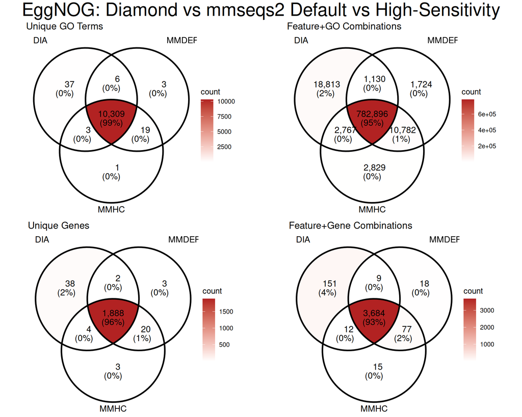

```r
p1 <- ggVennDiagram(list(DIA=egg_diamond_uniq, MMDEF=egg_mm_def_uniq, MMHC=egg_mm_HC_uniq), label_alpha = 0) +
  scale_fill_gradient(low="white", high="firebrick") +
  ggtitle("Unique GO Terms")

p2 <- ggVennDiagram(list(DIA=egg_diamond_featGO, MMDEF=egg_mm_def_featGO, MMHC=egg_mm_HC_featGO), label_alpha = 0) +
  scale_fill_gradient(low="white", high="firebrick") +
  ggtitle("Feature+GO Combinations")

p3 <- ggVennDiagram(list(DIA=egg_dia_genes, MMDEF=egg_mm_def_genes, MMHC=egg_mm_HC_genes), label_alpha = 0) +
  scale_fill_gradient(low="white", high="firebrick") +
  ggtitle("Unique Genes")

p4 <- ggVennDiagram(list(DIA=egg_diamond_featgen, MMDEF=egg_mm_def_featgen, MMHC=egg_mm_HC_featgen), label_alpha = 0) +
  scale_fill_gradient(low="white", high="firebrick") +
  ggtitle("Feature+Gene Combinations")

grid.arrange(p1, p2, p3, p4, ncol = 2,
             top = textGrob("EggNOG: Diamond vs mmseqs2 Default vs High-Sensitivity", gp=gpar(fontsize=25)))
```

Diamond results seem to be almost same as mmseqs2, but it may be slightly better as it picks up a few more GO-terms and genes (unique and per-feature).

## 3) InterProScan vs InterProScan+BLAST

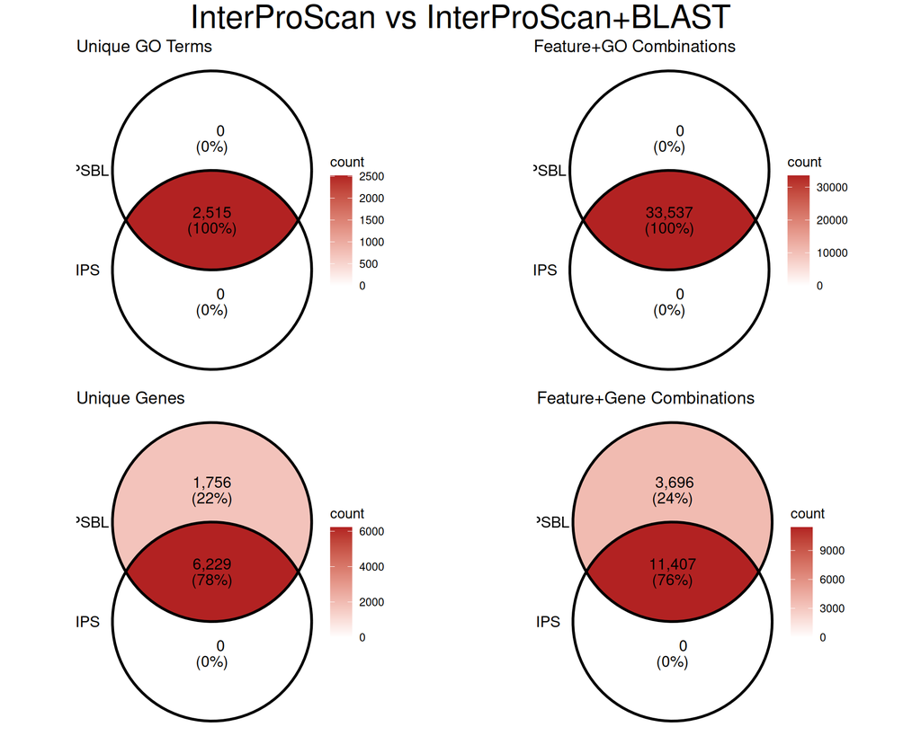

```r
p1 <- ggVennDiagram(list(IPS=interpro_uniq, IPSBL=interpro_blast_uniq), label_alpha = 0) +
  scale_fill_gradient(low="white", high="firebrick") +
  ggtitle("Unique GO Terms")

p2 <- ggVennDiagram(list(IPS=interpro_featGO, IPSBL=interpro_blast_featGO), label_alpha = 0) +
  scale_fill_gradient(low="white", high="firebrick") +
  ggtitle("Feature+GO Combinations")

p3 <- ggVennDiagram(list(IPS=interpro_genes, IPSBL=interpro_blast_genes), label_alpha = 0) +
  scale_fill_gradient(low="white", high="firebrick") +
  ggtitle("Unique Genes")

p4 <- ggVennDiagram(list(IPS=interpro_featgen, IPSBL=interpro_blast_featgen), label_alpha = 0) +
  scale_fill_gradient(low="white", high="firebrick") +
  ggtitle("Feature+Gene Combinations")

grid.arrange(p1, p2, p3, p4, ncol = 2,
             top = textGrob("InterProScan vs InterProScan+BLAST", gp=gpar(fontsize=25)))
```

As expected, there are no exclusive features to interproscan as this annotation is also included in the BLAST+Interpro annotation. This mainly serves to quantify how much more information is added by BLAST. BLAST itself doesn’t add information on GO-terms, so it only adds several new gene annotations.

## 4) mmseqs2, Diamond and InterProScan

I am including mmseqs2 only with high-sensitivity settings in this comparison as it had (only few) more annotated features than its default settings. First, without BLAST results, in case I see higher overlap between interproscan on its own and the eggnog approaches.

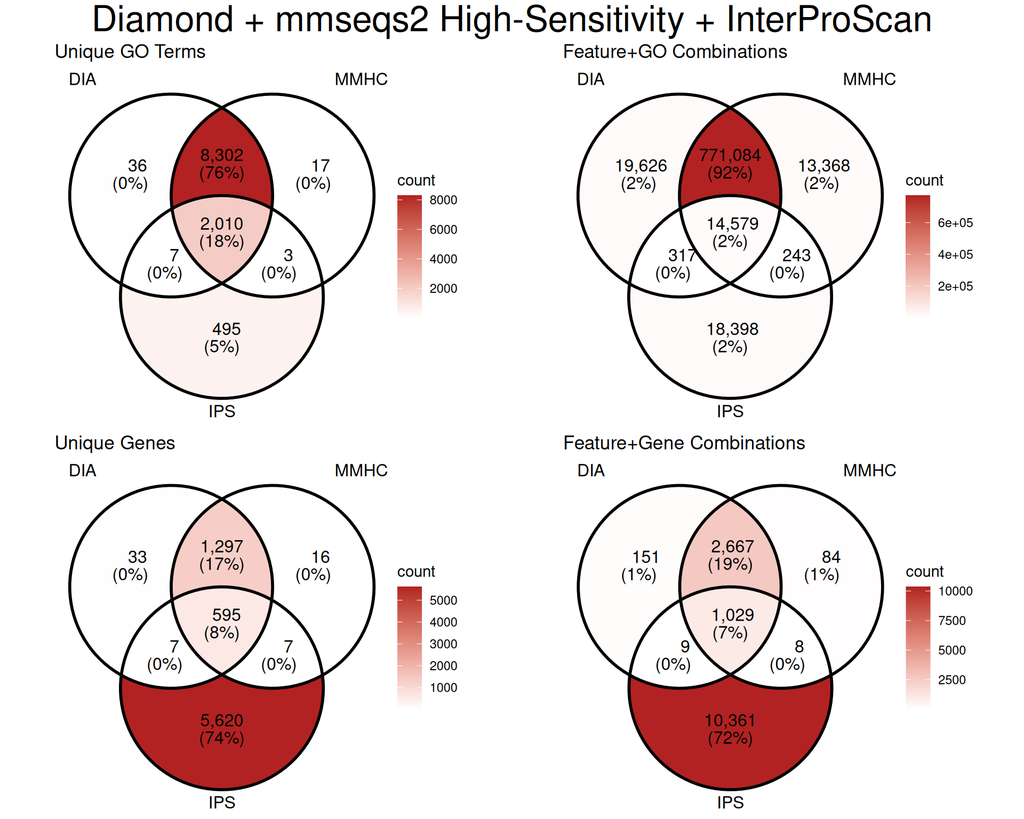

```r
p1 <- ggVennDiagram(list(DIA=egg_diamond_uniq, MMHC=egg_mm_HC_uniq, IPS=interpro_uniq), label_alpha = 0) +
  scale_fill_gradient(low="white", high="firebrick") +
  ggtitle("Unique GO Terms")

p2 <- ggVennDiagram(list(DIA=egg_diamond_featGO, MMHC=egg_mm_HC_featGO, IPS=interpro_featGO), label_alpha = 0) +
  scale_fill_gradient(low="white", high="firebrick") +
  ggtitle("Feature+GO Combinations")

p3 <- ggVennDiagram(list(DIA=egg_dia_genes, MMHC=egg_mm_HC_genes, IPS=interpro_genes), label_alpha = 0) +
  scale_fill_gradient(low="white", high="firebrick") +
  ggtitle("Unique Genes")

p4 <- ggVennDiagram(list(DIA=egg_diamond_featgen, MMHC=egg_mm_HC_featgen, IPS=interpro_featgen), label_alpha = 0) +
  scale_fill_gradient(low="white", high="firebrick") +
  ggtitle("Feature+Gene Combinations")

grid.arrange(p1, p2, p3, p4, ncol = 2,
             top = textGrob("Diamond + mmseqs2 High-Sensitivity + InterProScan", gp=gpar(fontsize=25)))
```

Highest overlap between the eggnog algorithms. But also very high proportion of gene annotations exclusive to interproscan.

## 5) mmseqs2, Diamond and InterProScan+BLAST

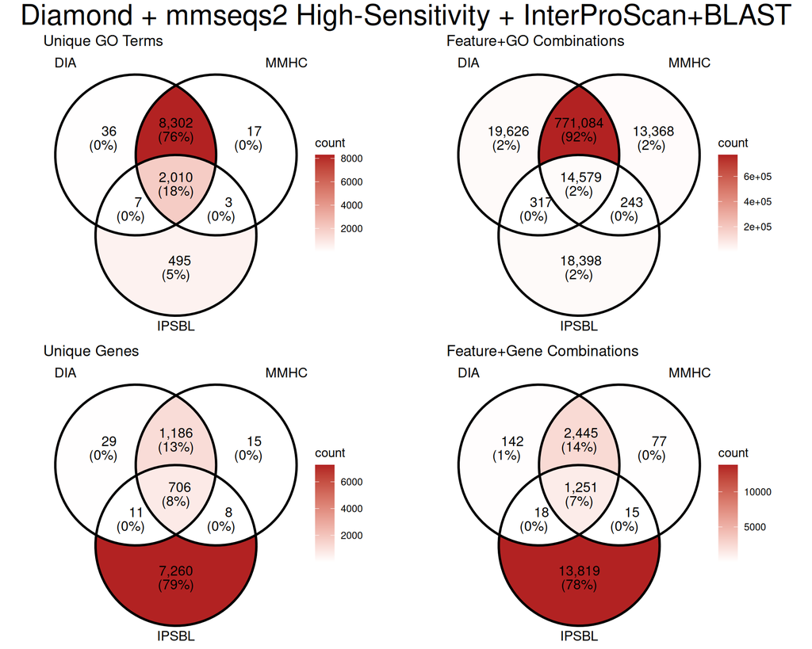

```r
p1 <- ggVennDiagram(list(DIA=egg_diamond_uniq, MMHC=egg_mm_HC_uniq, IPSBL=interpro_blast_uniq), label_alpha = 0) +
  scale_fill_gradient(low="white", high="firebrick") +
  ggtitle("Unique GO Terms")

p2 <- ggVennDiagram(list(DIA=egg_diamond_featGO, MMHC=egg_mm_HC_featGO, IPSBL=interpro_blast_featGO), label_alpha = 0) +
  scale_fill_gradient(low="white", high="firebrick") +
  ggtitle("Feature+GO Combinations")

p3 <- ggVennDiagram(list(DIA=egg_dia_genes, MMHC=egg_mm_HC_genes, IPSBL=interpro_blast_genes), label_alpha = 0) +
  scale_fill_gradient(low="white", high="firebrick") +
  ggtitle("Unique Genes")

p4 <- ggVennDiagram(list(DIA=egg_diamond_featgen, MMHC=egg_mm_HC_featgen, IPSBL=interpro_blast_featgen), label_alpha = 0) +
  scale_fill_gradient(low="white", high="firebrick") +
  ggtitle("Feature+Gene Combinations")

grid.arrange(p1, p2, p3, p4, ncol = 2,
             top = textGrob("Diamond + mmseqs2 High-Sensitivity + InterProScan+BLAST", gp=gpar(fontsize=25)))
```

Similar picture as just with interproscan, but BLAST with its additional gene annotations increases the fraction of genes annotated exclusively by interproscan+BLAST even further.

## Summary

- mmseqs2 settings don’t make as big of a difference as I expected
- Diamond seems to have a few more features than mmseqs2, but there are still a few exclusive annotations found by mmseqs2
- InterProScan adds many more genes terms not found by EggNOG, and adds a smaller fraction (5%) of additional GO-terms
- BLAST adds even more annotated genes

I will definitely merge the annotation of eggnog (Diamond) and interproscan+BLAST, as mmseqs2 still detects a few additional features, I would also add these on top in order to get a more complete picture.

Next step: BUSCO scores for each annotation.